# Téma 1

2024-10-06

```r
library(dplyr)
library(ggplot2)
library(readxl)
library(stringr)
library(RCzechia)
library(RColorBrewer)
library(sf)
```

## Úkol 1

Nejdříve načteme tři základní soubory, ze kterých budeme čerpat. Soubor s demografickými údaji (zajímá nás list s obyvatelstvem) si lehce upravíme, aby se s ním následně lépe pracovalo; ignorujeme první řádek (nepředstavuje sloupec, který bychom dále využívali) pomocí funkce **skip**. Stejně tak nás nezajímá celorepublikové údaje (první záznam), pouze samotné kraje, pomocí **slice** se jich tak můžeme zbavit. Po prohlédnutí ostatních Excel souborů dále můžeme vidět, že kraje se v nich objevují pouze ve formě jejich přívlastků, nikoli i s přídomkem “kraj”, pro snadnější spojování tak do takové podoby přetavíme i tento soubor. Hodnoty v sloupci *“Název kraje”* tak upravíme pomocí funkce **mutate**, ve které dále použijeme funkci **str_remove** pro odstranění řetězce *“kraj”* bez ohledu na velikost písma. V poslední řadě pak přejmenuje sloupec *“Zpět na obsah”* na *“Kód”*; jedná se spíše o estetickou volbu.

```r
obyvatelstvo <- read_excel("demogr.xlsx", sheet = "Obyvatelstvo", skip = 1) %>% slice(-1) %>%
  mutate(`Název kraje` = str_remove(`Název kraje`, "(?i)\\s*kraj\\s*")) %>%
  rename(Kód = `Zpět na obsah`)

sportovci <- read_excel("sportovci.xlsx")
organizace <- read_excel("organizace.xlsx")
```

Nyní nás zajímá, kolik je v jednotlivých krajích sportovců. Z pouze jednoho souboru to nezjistíme, musíme tedy organizace provázat s odpovídajími počty sportovců. Toho dosáhneme pomocí funkce **left_join**. Kvůli vysoké koncentraci stejných atributů ovšem nechceme ze sportovců přenést všechny atributy daného záznamu, ale pouze počet sportovců dané organizace a také klíč (v tomto případě “IČO”), který nám bude sloužit k provázání souborů. Nyní už máme v datasetu vše, co potřebujeme, můžeme tedy data seskupit dle krajů pomocí **group_by** a přiřadit k nim do atributu *“pocet_sportovcu”* celkový počet sportovců daného kraje.

```r
sportovci_organizace <- left_join(organizace %>% select(IČO, `Kraj`),
                        sportovci %>% select(IČO, `Počet sportovců`),
                        by = "IČO") %>%  group_by(`Kraj`) %>%
                        summarise(pocet_sportovcu = sum(`Počet sportovců`, na.rm = TRUE))
```

Už víme, kolik je celkový počet sportovců v daných krajích, nyní musíme určit procentuální podíl v rámci celkové populace kraje, spojíme tedy datasety *“obyvatelstvo”* a *“sportovci_organizace”*. Atributy *“Název kraje”* z obyvatelstva a *“Kraj”* ze sportovci_organizace jsou funkčně identické, v joinu to tak specifikujeme, aby mohly sloužit jako klíč. Po úspěšném propojení už můžeme konečně zjistit podíl v populaci, a to jako podíl počtu sportovců v kraji a celkovém počtu obyvatel k 31.12.2023.

```r
obyvatelstvo_SO <- inner_join(obyvatelstvo %>% select(Kód, `Název kraje`, `2023`), sportovci_organizace, by = c("Název kraje" = "Kraj"))
obyvatelstvo_SO <- obyvatelstvo_SO %>% mutate(sportovci_na_obyvatele = `pocet_sportovcu` / `2023`)
print(obyvatelstvo_SO)
```

```
## # A tibble: 14 × 5
##    Kód   `Název kraje`       `2023` pocet_sportovcu sportovci_na_obyvatele
##    <chr> <chr>                <dbl>           <dbl>                  <dbl>
##  1 CZ010 Hlavní město Praha 1384732          861958                  0.622
##  2 CZ020 Středočeský        1455940          196493                  0.135
##  3 CZ031 Jihočeský           654505          112509                  0.172
##  4 CZ032 Plzeňský            613374           94178                  0.154
##  5 CZ041 Karlovarský         295077           31744                  0.108
##  6 CZ042 Ústecký             811169           84538                  0.104
##  7 CZ051 Liberecký           450728           68950                  0.153
##  8 CZ052 Královéhradecký     556949           92848                  0.167
##  9 CZ053 Pardubický          530560           80752                  0.152
## 10 CZ063 Vysočina            517960           71112                  0.137
## 11 CZ064 Jihomoravský       1226749          187725                  0.153
## 12 CZ071 Olomoucký           632864           86605                  0.137
## 13 CZ072 Zlínský             580744           88800                  0.153
## 14 CZ080 Moravskoslezský    1189204          159183                  0.134
```

Vidíme, že největší počet sportovců na obyvatele má Praha, nejméně pak Ústecký kraj. Nyní už téměř můžeme výsledky zobrazit v rámci mapy, zbývá jen dataset s podílem spojit s datasetem mapy. Odpovídajícího vykreslení docílíme pomocí funkcí **gg_plot** a **geom_sf**.

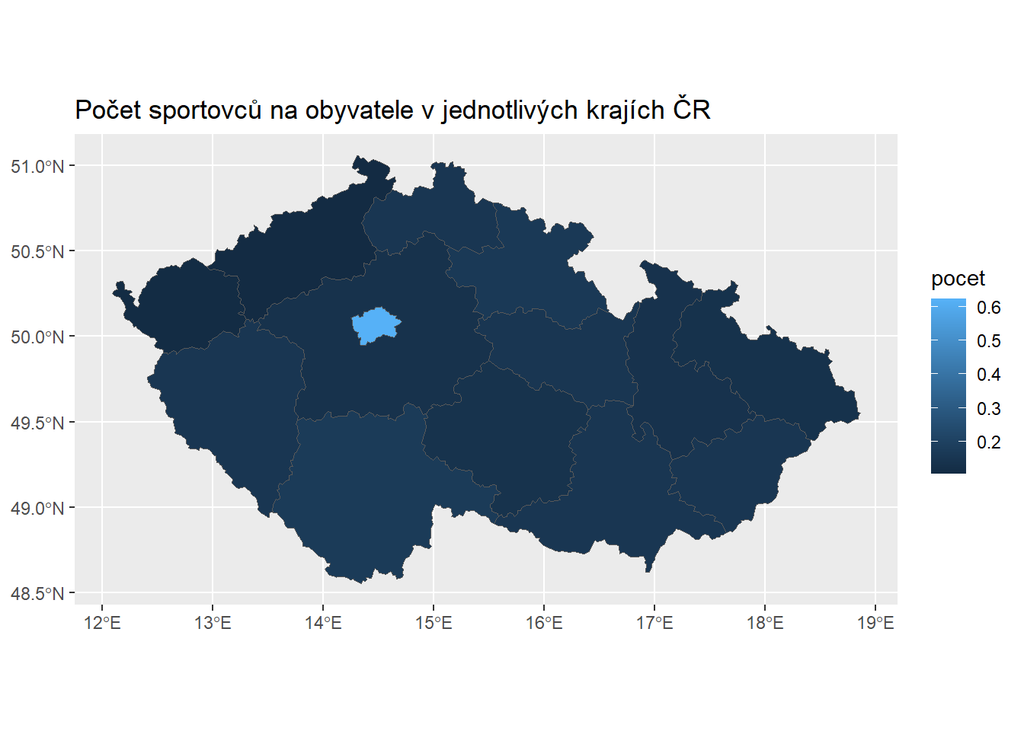

```r
mapa <- kraje("low")

mapa_sportovci <- mapa %>%
  left_join(obyvatelstvo_SO %>% select(Kód,sportovci_na_obyvatele), by = c("KOD_CZNUTS3" = "Kód"))

ggplot(mapa_sportovci) +
  geom_sf(aes(fill = sportovci_na_obyvatele)) +
  scale_fill_gradient(low = "#132b43", high = "#56b1f7") +
  labs(title = "Počet sportovců na obyvatele v jednotlivých krajích ČR",
       fill = "pocet")
```

## Úkol 2

### Otázka 1

Pomocí funkce **filter** můžeme omezit výběr záznamů pouze na ty, u nichž je hodnota atributu *““Stav”* nastavena na “Ověřeno”. Následně pomocí funkce **count** provedeme součet jednotlivých právních forem se sestupným řaděním a výběr omezíme pouze na 4 nejčastější.

```r
organizace_overeno <- organizace %>% filter(`Stav` == "Ověřeno")

organizace_top4 <- organizace_overeno %>%
  count(`Právní forma`, sort = TRUE) %>%
  slice_max(n, n = 4) %>% rename(`Celkový počet` = n)

print(organizace_top4)
```

```
## # A tibble: 4 × 2
##   `Právní forma`                `Celkový počet`
##   <chr>                                   <int>
## 1 Spolek                                   8900
## 2 Pobočný spolek                           5843
## 3 Příspěvková organizace                     33
## 4 Společnost s ručením omezeným              23
```

Nejčastější právní formou organizace tak je spolek, následován pobočným spolkem, a zbytek TOP4 dotváří příspěvková organizace a s.r.o. Nyní, když máme čtyři nejčastější právní formy, nás zajímá, jak si stojí v jednotlivých krajích. Vezmeme tedy dataset s ověřenými organizacemi, a vyfiltrujeme pouze ty, kde hodnota atributu *“Právná forma”* odpovídá jednomu ze čtyř nejčastějších. Zbylé záznamy pak seskupíme podle krajů a provedeme nad nimi celkový součet.

```r
poradi_kraje <- organizace_overeno %>%
  filter(`Právní forma` %in% organizace_top4$`Právní forma`) %>%
  group_by(Kraj, `Právní forma`) %>%
  summarise(pocet = n(), .groups = "drop") %>%
  arrange(Kraj, desc(pocet))
```

Jelikož nás zajímají výsledky ve všech krajích a pořadí se může měnit, zvolíme faceted bar chart, který vykreslí jednoduchý sloupcový graf s počtem daných právních forem organizací pro jednotlivé kraje.

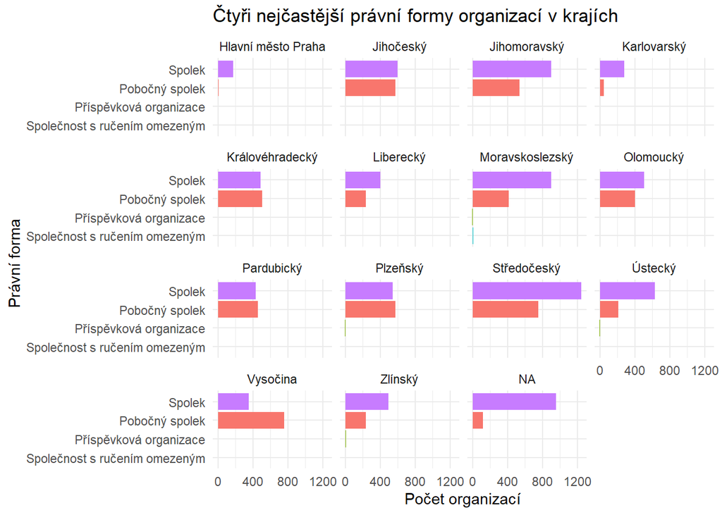

```r
ggplot(poradi_kraje, aes(x = reorder(`Právní forma`, pocet), y = pocet, fill = `Právní forma`)) +
  geom_bar(stat = "identity") +
  coord_flip() +
  facet_wrap(~ Kraj) +
  labs(title = "Čtyři nejčastější právní formy organizací v krajích",
       x = "Právní forma",
       y = "Počet organizací") +
  theme_minimal() +
  theme(legend.position = "none")
```

### Otázka 2

Nejdříve musíme zjistit, kolik mají ověřené organizace sportovců a trenérů. Toho docílíme pomocí spojení datasetu z předchozí otázky a datasetu sportovců. Následně chceme omezit záznamy, se kterými budeme dále pracovat, pouze na ty, jenž jsou pro nejčastější typ organizace. Toho docílíme pomocí výběru průniku mezi nimi. Nad daným průnikem pak můžeme zjistit celkový počet záznamů, které splňují stanové podmínky, a a uložit je do proměnných. Stejně tak do proměnné uložíme i celkový počet záznamů dané organizace.

```r
so_overeno <- left_join(organizace_overeno,
                        sportovci %>% select(IČO, `Počet sportovců`, `Počet trenérů`),
                        by = "IČO")
top_organizace <- organizace_overeno %>%
  count(`Typ organizace`, sort = TRUE) %>%
  slice_max(n, n = 1) %>% rename(`Celkový počet` = n)
print(top_organizace)
```

```
## # A tibble: 1 × 2
##   `Typ organizace` `Celkový počet`
##   <chr>                      <int>
## 1 Klub / TJ                  13574
```

```r
podil_sportovci <- inner_join(top_organizace, so_overeno, by = "Typ organizace") %>% filter(`Počet sportovců` > 0) %>% filter(`Počet trenérů` == 0) %>%
  nrow()
podil_treneri <- inner_join(top_organizace, so_overeno, by = "Typ organizace") %>% filter(`Počet sportovců` == 0) %>% filter(`Počet trenérů` > 0) %>%
  nrow()
celkovy_pocet <- top_organizace$`Celkový počet`
```

Nejčastějším typem ověřených organizací je, jak vidíme, Klub/TJ, s celkovým počtem 13574 záznamů. Když tedy máme všechny proměnné, snadno zjistíme celkové procentuální podíly, a výsledek vykreslíme pomocí Pie chartu.

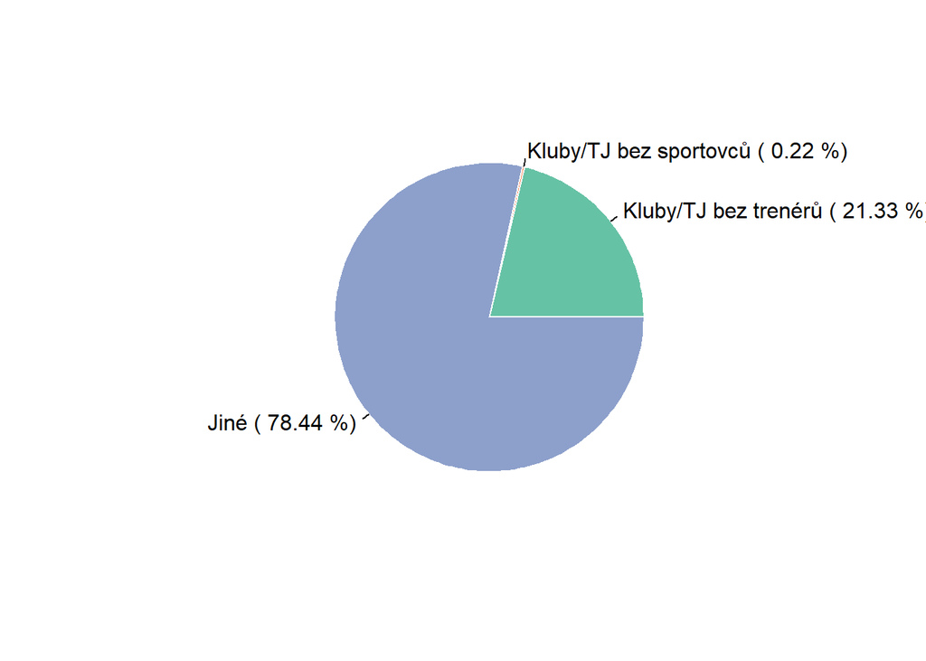

```r
podily <- c((podil_sportovci/celkovy_pocet) *100, (podil_treneri/celkovy_pocet) *100, ((celkovy_pocet - (podil_sportovci+podil_treneri)) /celkovy_pocet )*100)

labels <- c(
  paste("Kluby/TJ bez trenérů","(",round(podily[1], 2), "%)"),
  paste("Kluby/TJ bez sportovců", "(", round(podily[2], 2), "%)"),
  paste("Jiné", "(", round(podily[3], 2), "%)")
)

myPalette <- brewer.pal(5, "Set2")
pie(podily, labels = labels, border = "white", col = myPalette)
```

Kluby/TJ bez sportovců téměř nejsou zastoupeny, jejich podíl je 0.22 %. Kluby/TJ bez trenérů naopak tvoří více než pětinu všech existujících, s podílem 21.33 %. Zbytek klubů je pak pohodlná většina, s podílem 78.44 %

### Otázka 3

K detekci řetězce nám poslouží funkce **str_detect**. V regulárním výrazu pak specifikujeme, že se může jednat jak o “šach”, tak i “bridž”, a vlastnost *“ignore_case”* zařídí, že se nebude brát ohled na velikost písma. Výsledný výběr seskupíme podle krajů a vykreslíme pomocí bar chartu (sloupcového grafu).

```r
sach_bridz <- organizace_overeno %>% filter(str_detect(`Název`, regex("šach|bridž", ignore_case = TRUE)))
sb_kraj <- sach_bridz %>%
  group_by(Kraj) %>%
  summarise(`Celkový počet` = n())

print(sb_kraj)
```

```
## # A tibble: 15 × 2
##    Kraj               `Celkový počet`
##    <chr>                        <int>
##  1 Hlavní město Praha               4
##  2 Jihomoravský                     8
##  3 Jihočeský                        6
##  4 Karlovarský                      5
##  5 Královéhradecký                  5
##  6 Liberecký                        3
##  7 Moravskoslezský                  8
##  8 Olomoucký                        8
##  9 Pardubický                       7
## 10 Plzeňský                         5
## 11 Středočeský                     12
## 12 Vysočina                         5
## 13 Zlínský                          5
## 14 Ústecký                          5
## 15 <NA>                             8
```

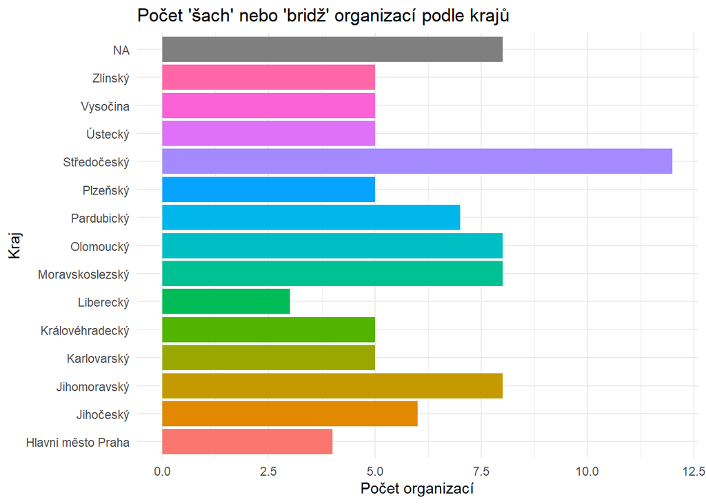

```r
ggplot(sb_kraj, aes(x = `Kraj`, y = `Celkový počet`, fill = `Kraj`)) +
  geom_bar(stat = "identity") +
  coord_flip() +
  labs(title = "Počet 'šach' nebo 'bridž' organizací podle krajů",
       x = "Kraj",
       y = "Počet organizací") +
  theme_minimal() +
  theme(legend.position = "none")
```

Nejvíce se takových organizací nachází ve Středočeském kraji (12), nejméně pak v kraji Libereckém (3).

## Úkol 3

Nejdřív vyfiltrujeme ověřené organizace, aby splňovaly omezení na počet sportovců/trenérů. Toho docílíme pomocí funkce **between**, která definuje povolený rozsah hodnot pro daný atribut.

```r
sportovci_filtered <- so_overeno  %>% filter(between(`Počet sportovců`, 1, 10000)) %>% filter(between(`Počet trenérů`, 1, 5000))
```

Pomocí funkce **lm** pak na výsledná data aplikujeme lineární regresivní model.

```r
model <- lm(`Počet sportovců` ~ `Počet trenérů`, data = sportovci_filtered)
print(model)
```

```
##
## Call:
## lm(formula = `Počet sportovců` ~ `Počet trenérů`, data = sportovci_filtered)
##
## Coefficients:
##     (Intercept)  `Počet trenérů`
##          91.793            8.658
```

Díky koeficientům vidíme, že organizace, které nemají žádné trenéry, mají v průměru 91.793 sportovců. S každým další trenér se počet sportovců zvedá o 8.66.

Data nyní vykreslíme spolu s nalezenou přímkou v rámci scatter plotu (bodový graf).

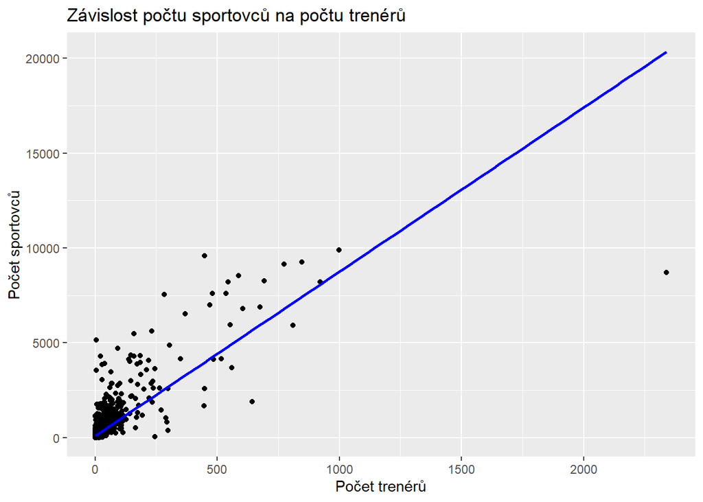

```r
ggplot(sportovci_filtered, aes(x = `Počet trenérů`, y = `Počet sportovců`)) +
  geom_point() +
  geom_smooth(method = "lm", se = FALSE, color = "blue", formula = y ~ x) +
  labs(title = "Závislost počtu sportovců na počtu trenérů",
       x = "Počet trenérů",
       y = "Počet sportovců")
```